# Preliminary-results.Rmd

Group_4

2022-12-10

## Preliminary Results

**1. Title** Assessment of water stress conditions in cultivated and wild species.

**2. Team members names** Carbajal J., Castanier J., Chiapparoli L., Puente M. (Group 4).

**4. Objectives and hypotheses.**

Objectives 1. Evaluate the effects of the water stress treatments on the growth, development and photosynthetic activity in nine different plant species. 2. Compare the responses to drought conditions between cultivated crops and weeds, and determine if there are significant differences.

Hypotheses - H1,0: There will be no significant effects of the water stress treatments on the growth, development and photosynthetic activity in the nine tested plant species. - H1,1: There will be significant effects of the water stress treatments on the growth, development and photosynthetic activity in the nine tested plant species. - H2,0: There will be no significant differences on the growth, development and photosynthetic activity of plants from the water treatments between crops and weeds. - H2,1: There will be significant differences in growth, development and photosynthetic activity of plants from the water treatments between crops and weeds.

**5. Methods. What have you done? And what did you use to do it? Step by step, so anyone could do it again by reading this part.** Trial establishment. Experiments were carried out by 5 groups of students. Each group was in charge of 2 species (one crop, one weed). (One species was repeated by two groups). Each species was subjected to 3 treatments or water stress levels (C, I, WS). Each group had 3 plastic trays (cmxcm), one tray for each WS treatment. Each tray contained 7 plants of each species (7+7=14 plants/tray). Each group worked with 42 potted plants, with a total of 210 experimental units (42x5) for the 5 groups and 9 plant species.

Plant Material. A total of 9 species were evaluated under water stress conditions. The species were: Amaranthus retroflexus, Beta vulgaris, Hordeum vulgare, Lolium perenne, Portulacea oleracea, Raphanus sativus, Solanum lycopersicum, Sonchus oleraceus, and Spinacia oleracea.

Pot and substrate preparation. Each one of the five groups washed and prepared a total of 42 pots (1L). A circular piece of paper was cut and located in the base of pots for avoiding substrate loss and promoting water absorption from trays. For the preparation of substrate, we used a combination of peat moss and perlite in a ratio of 3:1 respectively. We mixed the components homogeneously in a large bucket and added a total of 4.5 L of water. The pots were filled with substrate all the way to the top and located in the trays, with 14 pots per tray.

Transplant. Transplant of 1 week old seedlings into the pots, one plant per pot. Addition of labels indicating species, treatment and repetition numbers. Initial watering of all plants (1.5-2 L/tray). Sowing date: 21/9/2022. Transplant date: 28/9/2022.

Water stress treatments: C / I / WS.

| Date | Week | Amount of water per treatment (L) |
| --- | --- | --- |
| 05/10/2022 | (W1) | 2L / 1L / 0L |
| 13/10/2022 | (W2) | 2L / 1L / 0L |
| 19/10/2022 | (W3) | 2L / 1L / 0L |
| 26/10/2022 | (W4) | 2L / 1L / 1L |
| 02/11/2022 | (W5) | 2L / 1L / 0.5L |
| 09/11/2022 | (W6) | 2L / 1L / 0.5L |

A total of 13 numerical response variables were registered for their analyses: Soil Humidity (SH), Electrical Conductivity (EC), Plant Height (PH), Number of Leaves (NL), Leaf Length (LL), Leaf Width (LW), Chlorophyll Content (CC), Leaf Area (LA), Aerial Fresh Weight (AFW), Aerial Dry Weight (ADW), Root Length (RL), Root Fresh Weight (RFW), Root Dry Weight (RDW). Two additional variables are going to be analyzed but are not yet added to the final data frame, these are Aerial Water Content (AWC), Root Water Content (RWC).

**Data recollection** - Soil Humidity SH (%) and Electrical Conductivity EC (mS/cm) were measured with HH2 Moisture Meter (Delta-T Devices, Cambridge-England). - Number of Leaves (NL) was counted visually, excluding cotyledons. - Plant Height (PH), Leaf Length (LL) and Leaf Width (LW) were measured with a standard metallic ruler in centimeters (cm). - Chlorophyll Content (CC): measured with SPAD (SPAD units). - Leaf Area LA (cm2) and Root Length RL (cm) were measured only in W6 after sampling, with Digimizer and ImageJ software. - Aerial Fresh Weight (AFW) and Root Fresh Weight (RFW) were measured with an electronic scale in grams (g). - Aerial Dry Weight (ADW) and Root Dry Weight (RDW) were measured with electronic scale in grams (g), after samples were dried in an oven (70*C, 7 days). - Aerial Water Content (AWC) and Root Water Content (RWC) were calculated from fresh and dry weights and the following formula: WC=(FW-DW)/FW x100.

**Overview of the statistical analyses to be performed**

Plant parameters to be analyzed: - Leaf Number - Chlorophyll content (W6) - Aerial Fresh Weight - Aerial Dry Weight - Aerial Water Content - Root Length - Root Fresh Weight - Root Dry Weight - Root Water Content

Categorical parameters: - Species - Date - Week - Use - Treatment - Plant ID First hypothesis:

```
- Main test: One-way ANOVA
Categorical variables: treatments
Dependent variables: plant parameters
Calculate one parameter at a time

*Parameters to control:*
- Date
- Species
```

Secondary tests: - Shapiro–Wilk test for normality of residuals - TukeyHSD test (PostHoc test) to recognize different groups from ANOVA - Kruskal Wallis as Non-parametric test

Second hypothesis:

- Main test: Two way ANOVA Categorical variables: treatment and use Dependent variables: plant parameters Calculate one parameter at a time

*Parameters to control:* - Date - Species

Secondary tests: - Shapiro–Wilk test for normality of residuals - TukeyHSD test (PostHoc test) to recognize different groups from ANOVA - Kruskal Wallis as Non-parametric test

** First Hypothesis**

*Statistical analyses*

**Look over the raw data plots** We reviewed the raw data plots and decide the numerical variables to focus on. The analyses were made on the data of the final week (week 6) because for most variables the data was only available for week 6 and there were few dead plants at the end of the experiment.

```r
#### Install packages --------------
#install.packages(c("dplyr", "tidyr"), dependencies = TRUE)
#install.packages(c("tidyverse"), dependencies = TRUE)
#install.packages("ggplot2", dependencies = TRUE)

#### Packages ------------
library(dplyr)
library(tidyr)
library(tidyverse)
library(ggplot2)
library(agricolae)

#### Calling the other scripts to call data ---
#Comment this after getting the data
source("R/00_download-from-drive.R")
```

[output not shown]

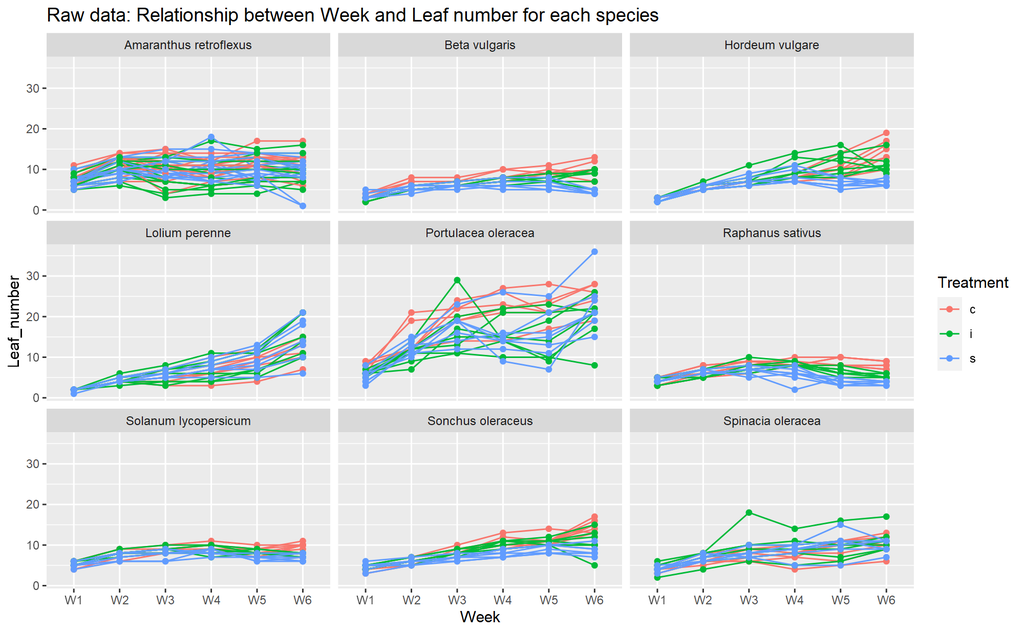

```r
source("R/01_check-data.R")

#### Creating duplicate of the original data ------

data1 <- ws0

#### Adding columns to calculate water content for Aerial material and Root

data1 <- mutate(data1,
            Aerial_water_content =
              (Aerial_fresh_weight - Aerial_dry_weight)/Aerial_fresh_weight)

data1 <- mutate(data1,
       Root_water_content =
         (Roots_fresh_weight - Roots_dry_weight)/Roots_fresh_weight)


#### Plant parameters to measure

parameters <- c("Week", 'Date','Species', 'PlantId', 'Use', 'Treatment',
                "Leaf_number", "Chlorophyll_content",
                "Aerial_fresh_weight", "Aerial_dry_weight",
                "Root_length", "Roots_fresh_weight",
                "Roots_dry_weight", "Aerial_water_content",
                "Root_water_content")


#### variables to be used
numerical_var <- c("Leaf_number", "Chlorophyll_content",
                   "Aerial_fresh_weight", "Aerial_dry_weight",
                   "Root_length", "Roots_fresh_weight",
                   "Roots_dry_weight", "Aerial_water_content",
                   "Root_water_content")

#### GGPLOTS for Raw Data only ----------

#Leaf number
data1 %>% ggplot(aes(x = Week, y = Leaf_number, group = PlantId,
  col = Treatment)) + geom_line() + geom_point()+
  facet_wrap(~Species) +
  ggtitle("Raw data: Relationship between Week and Leaf number for each species")
```

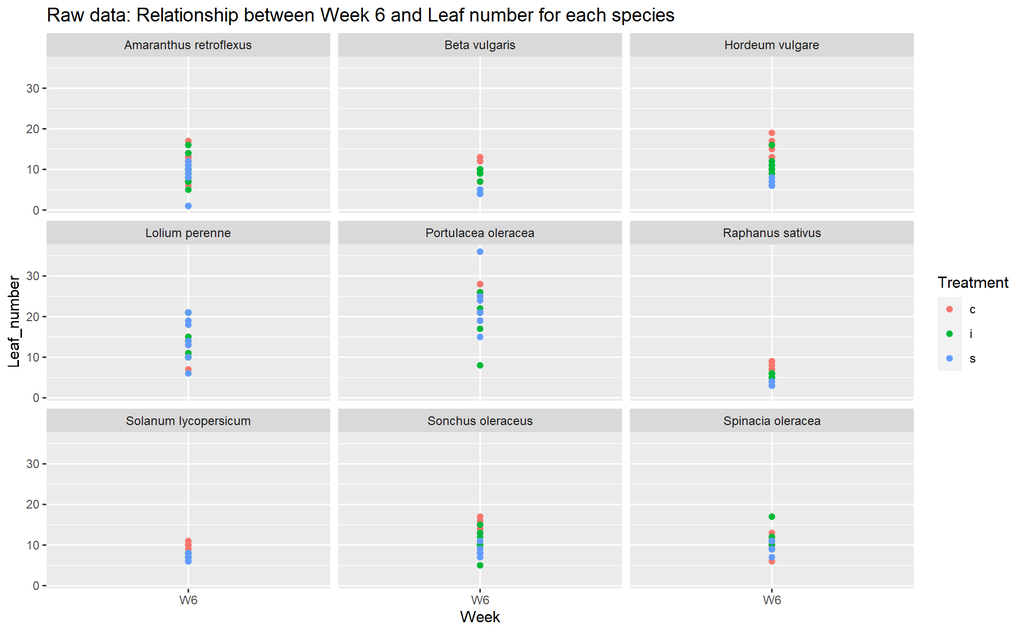

```r
#Leaf number in week 6
data1 %>% filter(Week == "W6") %>%
  ggplot(aes(x = Week, y = Leaf_number, group = PlantId,
  col = Treatment)) + geom_point()+
  facet_wrap(~Species) +
  ggtitle("Raw data: Relationship between Week 6 and Leaf number for each species")
```

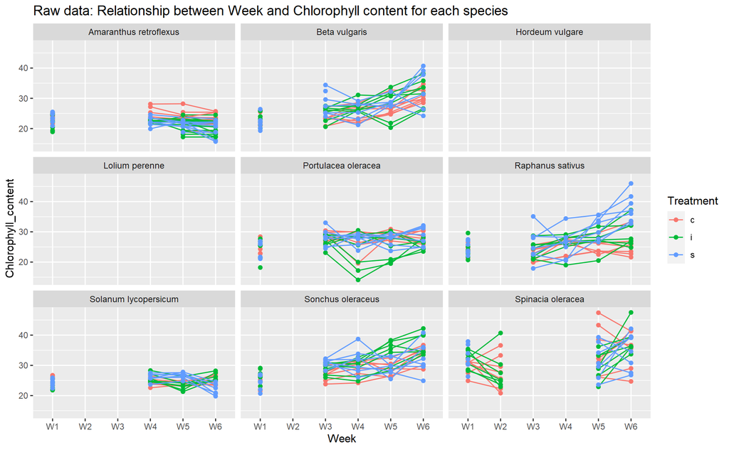

```r
#Chlorophyll content
data1 %>% ggplot(aes(x = Week, y = Chlorophyll_content, group = PlantId,
  col = Treatment)) + geom_line() + geom_point() +
  facet_wrap(~Species) +
  ggtitle("Raw data: Relationship between Week and Chlorophyll content for each species")
```

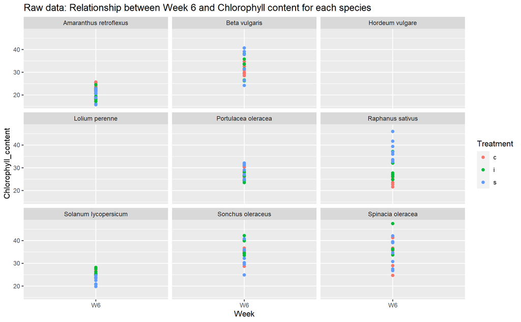

```r
#Chlorophyll content in week 6
data1 %>% filter(Week == "W6") %>%
  ggplot(aes(x = Week, y = Chlorophyll_content, group = PlantId,
  col = Treatment)) + geom_point() +
  facet_wrap(~Species) +
  ggtitle("Raw data: Relationship between Week 6 and Chlorophyll content for each species")
```

**Running ANOVA tests on plant parameters**

ANOVA analyses were used to determine significant differences of the 3 treatments on the following plant parameters: leaf number, (leaf area), chlorophyll content, root length, aerial fresh weight, aerial dry weight, root fresh weight, root dry weight, aerial water content, root water content.

Specifically, the analysis was made with the “aov” function on R comparing the plant parameter and treatment, excluding the effects of date and species, and then the Tukey’s HSD test was performed to determine the significant differences between the treatment (command “HSD.test” from the “agricolae” package). For the “leaf number parameter”, the ANOVA was performed with the square roots of the original values, since it should follow a Poisson distribution, and so with the square root values the distribution would be more normal.

For aerial water content and root water content the Kruskal-Wallis non-parametric test was used, since they are percentage values and they don’t follow normal distributions. The command “Kruskal” was used to perform this last analysis.

```r
#### Week we want to focus on

w <- "W6"

data2 <- data1 %>% filter(Week == w) %>% select(all_of(parameters))

#### ANOVAs and Tukey tests for the plant parameters

#ANOVA of leaf number with square root values

Sqrt_leaf_number <- sqrt(data2$Leaf_number)
a1_leafnumb1 <- aov(Sqrt_leaf_number ~ Treatment+Date+Species, data = data2)
summary.aov(a1_leafnumb1)
```

```
##              Df Sum Sq Mean Sq F value   Pr(>F)
## Treatment     2   9.92   4.962   21.30 4.18e-09 ***
## Date          1   4.99   4.989   21.42 6.68e-06 ***
## Species       7  70.23  10.033   43.07  < 2e-16 ***
## Residuals   198  46.12   0.233
## ---
## Signif. codes:  0 '***' 0.001 '**' 0.01 '*' 0.05 '.' 0.1 ' ' 1
## 1 observation deleted due to missingness
```

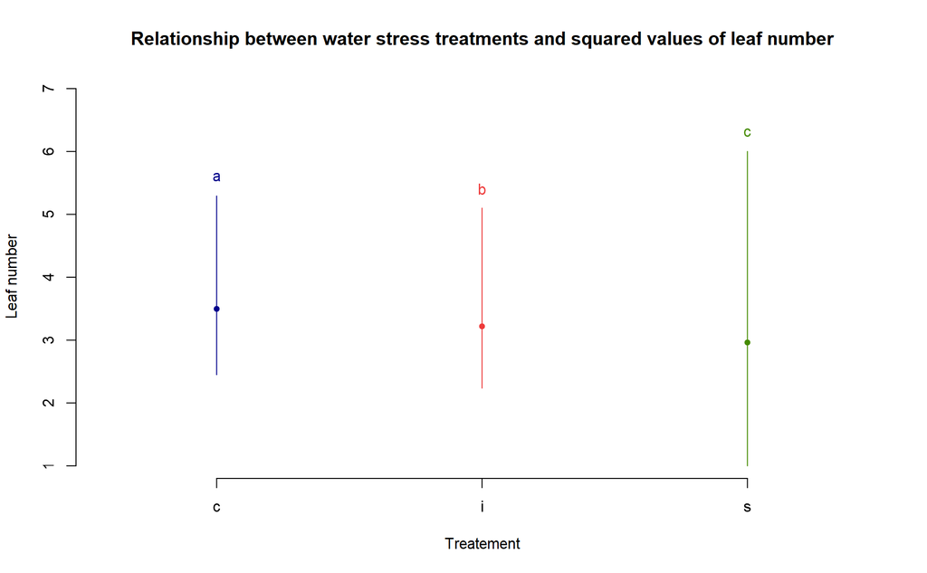

```r
#Tukey
TUKEY_leafnumb1 <- agricolae::HSD.test(a1_leafnumb1, "Treatment", group = TRUE)

#Plot
plot(TUKEY_leafnumb1, main = "Relationship between water stress treatments and squared values of leaf number", xlab = "Treatement", ylab = "Leaf number")
```

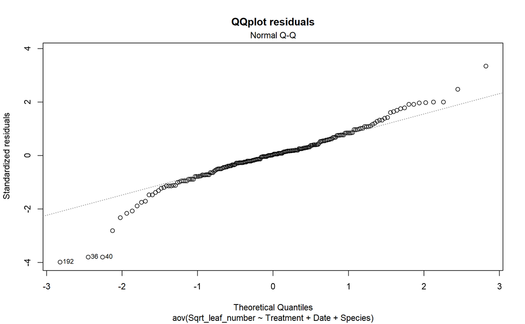

```r
#Shapiro Test for normality
shap_leafnumb1<- shapiro.test(a1_leafnumb1$residuals)
plot(a1_leafnumb1,2, main = "QQplot residuals")
```

```r
# ANOVA of Chlorophyll content with square root values

a1_chlorcont <- aov(Chlorophyll_content ~ Treatment+Date+Species, data = data2)
summary.aov(a1_chlorcont)
```

```
##              Df Sum Sq Mean Sq F value Pr(>F)
## Treatment     2     21    10.4   0.591  0.555
## Date          1     32    32.4   1.847  0.176
## Species       5   4800   960.1  54.721 <2e-16 ***
## Residuals   158   2772    17.5
## ---
## Signif. codes:  0 '***' 0.001 '**' 0.01 '*' 0.05 '.' 0.1 ' ' 1
## 43 observations deleted due to missingness
```

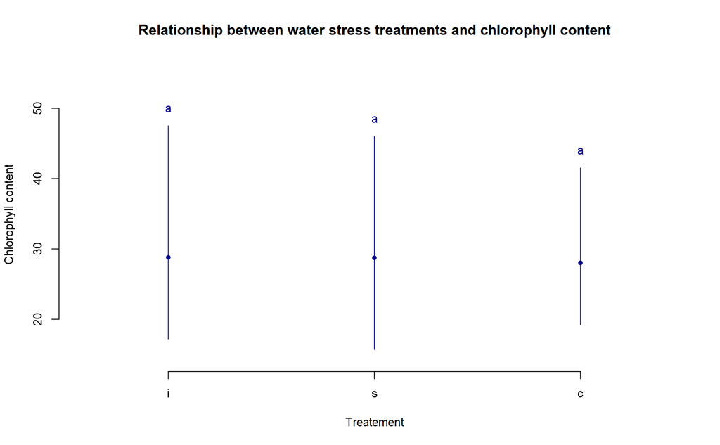

```r
#Tukey
TUKEY_chlorcont <- agricolae::HSD.test(a1_chlorcont, "Treatment", group = TRUE)
plot(TUKEY_chlorcont, main = "Relationship between water stress treatments and chlorophyll content", xlab = "Treatement", ylab = "Chlorophyll content")
```

```r
# ANOVA of Root length with square root values
a1_rlength <- aov(Root_length ~ Treatment+Date+Species, data = data2)
summary.aov(a1_rlength)
```

```
##              Df Sum Sq Mean Sq F value  Pr(>F)
## Treatment     2    131    65.6   1.407 0.24805
## Date          1    465   464.6   9.964 0.00192 **
## Species       6  12470  2078.4  44.569 < 2e-16 ***
## Residuals   155   7228    46.6
## ---
## Signif. codes:  0 '***' 0.001 '**' 0.01 '*' 0.05 '.' 0.1 ' ' 1
## 45 observations deleted due to missingness
```

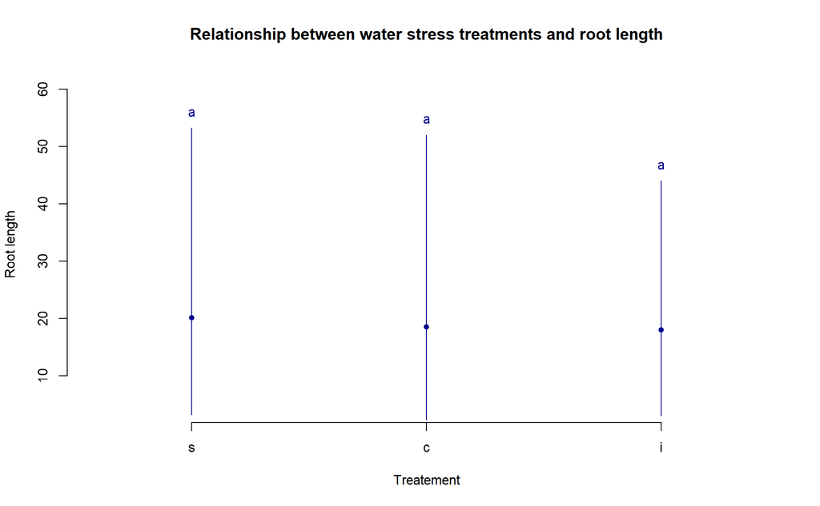

```r
#Tukey
TUKEY_rlength <- agricolae::HSD.test(a1_rlength, "Treatment", group = TRUE)
plot(TUKEY_rlength, main = "Relationship between water stress treatments and root length", xlab = "Treatement", ylab = "Root length")
```

```r
# ANOVA of Aerial fresh weight with square root values
a1_aerfw <- aov(Aerial_fresh_weight ~ Treatment+Date+Species, data = data2)
summary.aov(a1_aerfw)
```

```
##              Df Sum Sq Mean Sq F value Pr(>F)
## Treatment     2   1674   836.9   62.44 <2e-16 ***
## Date          1     84    84.0    6.27 0.0131 *
## Species       7   5468   781.2   58.29 <2e-16 ***
## Residuals   198   2654    13.4
## ---
## Signif. codes:  0 '***' 0.001 '**' 0.01 '*' 0.05 '.' 0.1 ' ' 1
## 1 observation deleted due to missingness
```

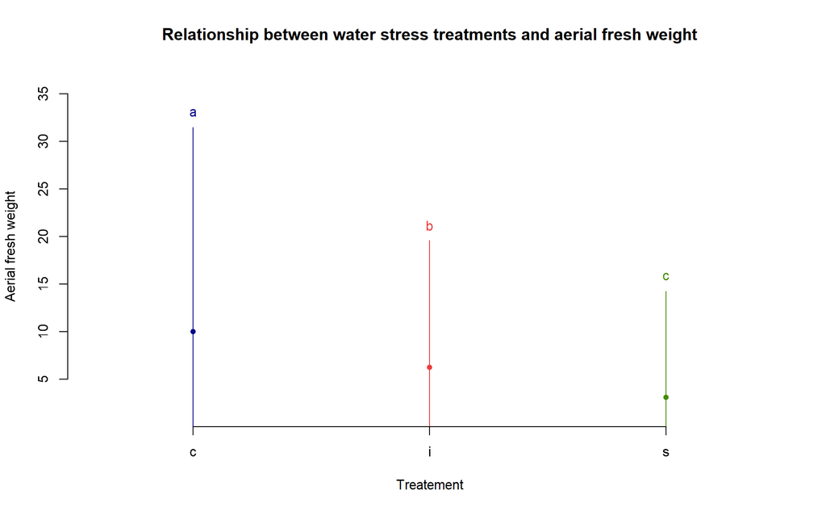

```r
#Tukey
TUKEY_aerfw <- agricolae::HSD.test(a1_aerfw, "Treatment", group = TRUE, )
plot(TUKEY_aerfw, main = "Relationship between water stress treatments and aerial fresh weight", xlab = "Treatement", ylab = "Aerial fresh weight")
```

```r
# ANOVA of Aerial dry weight with square root values
a1_aerdw <- aov(Aerial_dry_weight ~ Treatment+Date+Species, data = data2)
summary.aov(a1_aerdw)
```

```
##              Df Sum Sq Mean Sq F value   Pr(>F)
## Treatment     2   2.50   1.250  16.463 2.52e-07 ***
## Date          1   0.35   0.354   4.662   0.0321 *
## Species       7  52.95   7.565  99.664  < 2e-16 ***
## Residuals   192  14.57   0.076
## ---
## Signif. codes:  0 '***' 0.001 '**' 0.01 '*' 0.05 '.' 0.1 ' ' 1
## 7 observations deleted due to missingness
```

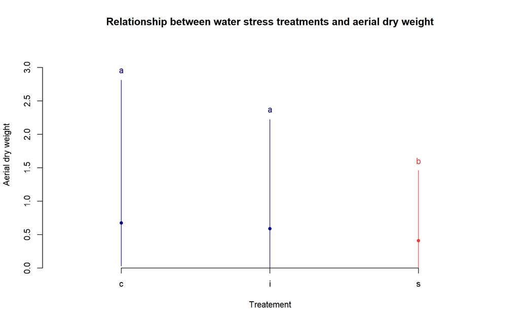

```r
#Tukey
TUKEY_aerdw <- agricolae::HSD.test(a1_aerdw, "Treatment", group = TRUE)
plot(TUKEY_aerdw, main = "Relationship between water stress treatments and aerial dry weight", xlab = "Treatement", ylab = "Aerial dry weight")
```

```r
# ANOVA of Root fresh weight with square root values
a1_rootfw <- aov(Roots_fresh_weight ~ Treatment+Date+Species, data = data2)
summary.aov(a1_rootfw)
```

```
##              Df Sum Sq Mean Sq F value   Pr(>F)
## Treatment     2   46.6   23.28   10.47 4.79e-05 ***
## Date          1  260.6  260.64  117.28  < 2e-16 ***
## Species       7  679.2   97.03   43.66  < 2e-16 ***
## Residuals   194  431.1    2.22
## ---
## Signif. codes:  0 '***' 0.001 '**' 0.01 '*' 0.05 '.' 0.1 ' ' 1
## 5 observations deleted due to missingness
```

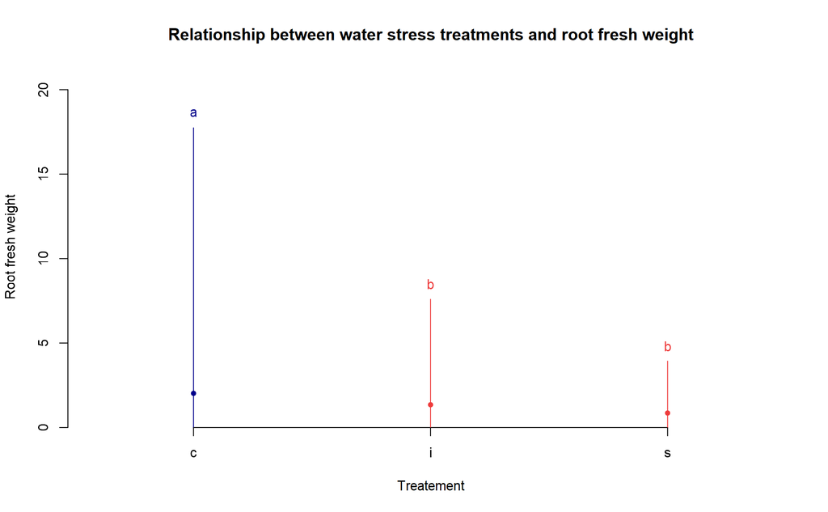

```r
#Tukey
TUKEY_rootfw <- agricolae::HSD.test(a1_rootfw, "Treatment", group = TRUE)
plot(TUKEY_rootfw, main = "Relationship between water stress treatments and root fresh weight", xlab = "Treatement", ylab = "Root fresh weight")
```

```r
# ANOVA of Root dry weight with square root values
a1_rootdw <- aov(Roots_dry_weight ~ Treatment+Date+Species, data = data2)
summary.aov(a1_rootdw)
```

```
##              Df Sum Sq Mean Sq F value Pr(>F)
## Treatment     2  0.023  0.0117   0.688  0.504
## Date          1  0.025  0.0246   1.454  0.230
## Species       7 11.270  1.6100  95.026 <2e-16 ***
## Residuals   181  3.067  0.0169
## ---
## Signif. codes:  0 '***' 0.001 '**' 0.01 '*' 0.05 '.' 0.1 ' ' 1
## 18 observations deleted due to missingness
```

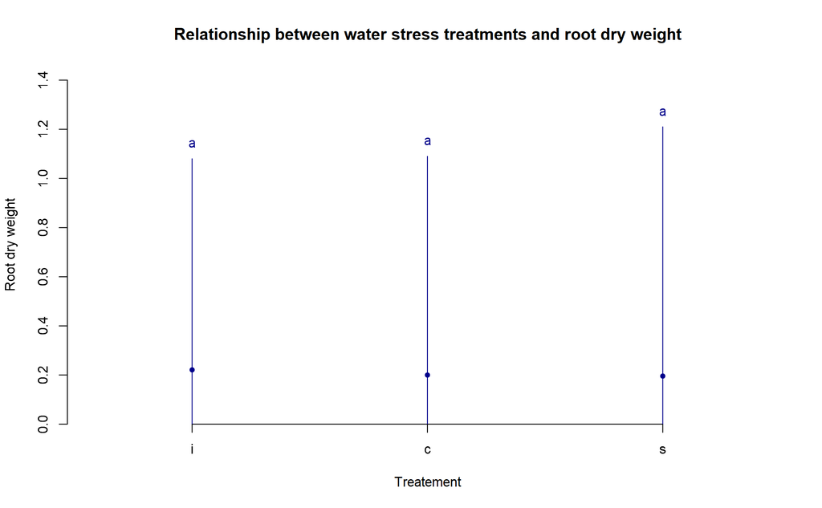

```r
#Tukey
TUKEY_rootdw <- agricolae::HSD.test(a1_rootdw, "Treatment", group = TRUE)
plot(TUKEY_rootdw, main = "Relationship between water stress treatments and root dry weight", xlab = "Treatement", ylab = "Root dry weight")
```

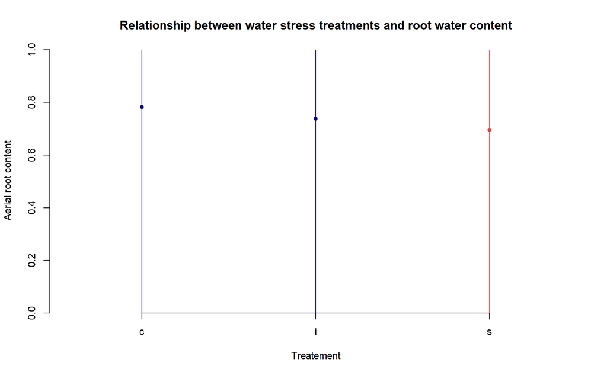

```r
# Kruskal Wallis test for water content
KWtest_rootwc <- with(data2, kruskal(Root_water_content, Treatment, group=TRUE))

# Kruskal-Wallis rank sum test
plot(KWtest_rootwc, main = "Relationship between water stress treatments and root water content", ylim = c(0,1),xlab = "Treatement", ylab = "Aerial root content")
```

```r
# ANOVA of Aerial water content with square root values
a1_aerwc <- aov(Aerial_water_content ~ Treatment+Date+Species, data = data2)
summary.aov(a1_aerwc)
```

```
##              Df Sum Sq Mean Sq F value Pr(>F)
## Treatment     2   12.2   6.104   0.839  0.434
## Date          1    2.0   1.978   0.272  0.603
## Species       7   26.9   3.845   0.529  0.812
## Residuals   191 1389.0   7.272
## 8 observations deleted due to missingness
```

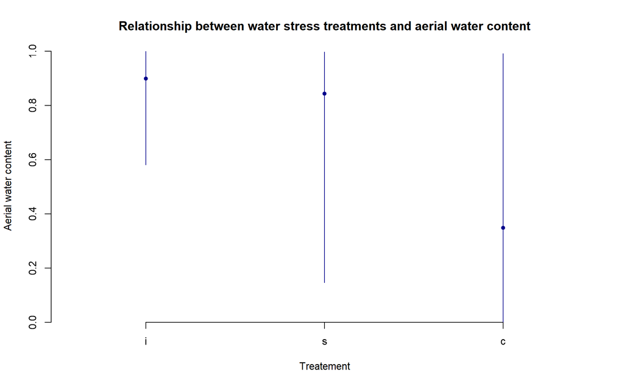

```r
#Tukey
TUKEY_aerwc <- agricolae::HSD.test(a1_aerwc, "Treatment", group = TRUE)
plot(TUKEY_aerwc, main = "Relationship between water stress treatments and aerial water content", xlab = "Treatement", ylab = "Aerial water content", ylim = c(0,1))
```

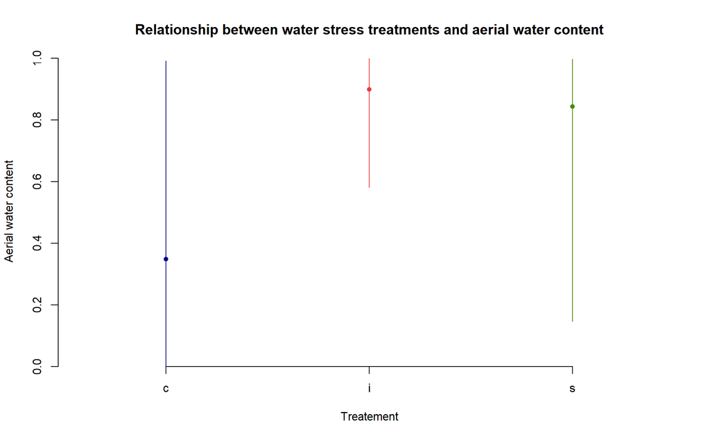

```r
#Shapiro test
shap_aerwc <-shapiro.test(a1_aerwc$residuals)


# Kruskal Wallis test for water content
KWtest_aerwc <- with(data2, kruskal(Aerial_water_content, Treatment, group=TRUE))

# Kruskal-Wallis rank sum test
plot(KWtest_aerwc, main = "Relationship between water stress treatments and aerial water content", ylim = c(0,1),xlab = "Treatement", ylab = "Aerial water content")
```

**Displaying nicely the p-values from ANOVA tests**

We could not show a table to display nicely the p-values directly from ANOVA tests on different numerical variables because the `{r} aov()` function does not recognize the levels in Treatment (the model was always NULL). We would highly appreciate some feedback on the bugs.

We formed a table by “hand” with the p-values for each numerical values and determine whether there was any significant group or not (p-value < 0.05).

```r
v_names <- c("Leaf_number_sqrt","Chlorophyll_content", "Root_length",
           "Aerial_fresh_weight","Aerial_dry_weight",
           "Roots_fresh_weight", "Roots_dry_weight", "Aerial_water_content")

p_value <- c(4.18e-09, 0.555, 0.24805, 2e-16, 2.52e-07, 4.79e-05, 0.504, 0.434)
sd_nsd <- c("Significantly different", "Not significantly different",
           "Not significantly different","Significantly different",
           "Significantly different", "Significantly different",
           "Not significantly different", "Not significantly different")
cn <- c("Variables", "P_values", "Significance")

p_table <- as.data.frame(matrix(nrow = length(v_names), ncol = length(cn)))

names(p_table) <- cn
p_table$Variables <- v_names
p_table$P_values <- p_value
p_table$Significance <- sd_nsd

#Knit table
knitr::kable(p_table, caption = 'Summary table for p values from ANOVA tests for different plant variables. Anova tests were carried out to detect the effect of treatment. The effect of Species and Week were controled.')
```

Summary table for p values from ANOVA tests for different plant variables. Anova tests were carried out to detect the effect of treatment. The effect of Species and Week were controled.

| Variables | P_values | Significance |
| --- | --- | --- |
| Leaf_number_sqrt | 0.0000000 | Significantly different |
| Chlorophyll_content | 0.5550000 | Not significantly different |
| Root_length | 0.2480500 | Not significantly different |
| Aerial_fresh_weight | 0.0000000 | Significantly different |
| Aerial_dry_weight | 0.0000003 | Significantly different |
| Roots_fresh_weight | 0.0000479 | Significantly different |
| Roots_dry_weight | 0.5040000 | Not significantly different |
| Aerial_water_content | 0.4340000 | Not significantly different |

**Displaying the differences among treatment groups for each plant species based on plant parameters**

- We want to make a table showing 5 columns: species, variables and treatment levels. The columns of the treatment levels will show the groups that are significant different between each other.

We could not show a table to display nicely the different groups from the linear tests on different numerical variables because the PostHoc test could not be run (it was always NULL). We would highly appreciate some feedback on the bugs.

**Second Hypothesis**

It is not possible to have discussion now because these are preliminary results, so it is necessary to wait until the final results are obtained.

8. Conclusion

It is not possible to have conclusions now because these are preliminary results, so it is necessary to wait until the final results are obtained.

9. Next steps in the analysis

-Finish up the results of the second hypothesis. -Create a table for the ANOVA´s p-values. -Create bar plots for all the results. -Complete point 7 (discussion) and point 8 (conclusion). -Create the final presentation of the project with the final results.